# Practical Machine Learning Project Write-up

Jaana Y.

November 13, 2016

## Background

Using devices such as Jawbone Up, Nike FuelBand, and Fitbit it is now possible to collect a large amount of data about personal activity relatively inexpensively. These type of devices are part of the quantified self movement - a group of enthusiasts who take measurements about themselves regularly to improve their health, to find patterns in their behavior, or because they are tech geeks. One thing that people regularly do is quantify how much of a particular activity they do, but they rarely quantify how well they do it. In this project, your goal will be to use data from accelerometers on the belt, forearm, arm, and dumbell of 6 participants. They were asked to perform barbell lifts correctly and incorrectly in 5 different ways. More information is available from the website here: http://groupware.les.inf.puc-rio.br/har (see the section on the Weight Lifting Exercise Dataset).

## Packages used

```r
library(caret)
library(randomForest)
library(rpart)
library(rpart.plot)
```

## Getting the data

The training data for this project are available here: https://d396qusza40orc.cloudfront.net/predmachlearn/pml-training.csv

The test data are available here: https://d396qusza40orc.cloudfront.net/predmachlearn/pml-testing.csv

The data for this project come from this source: http://groupware.les.inf.puc-rio.br/har

The data can be downloaded using code or clicking on the links above. Since the data was already saved to the the writer’s local machine during the process of completing this project, the import code was inactivated, but is included below for review.

```r
## trainURL <- https://d396qusza40orc.cloudfront.net/predmachlearn/pml-training.csv  ## Training dataset
trainFILE <- "pml-training.csv"
#download.file(url=trainURL, na.strings = c("NA", ""), header = TRUE)

## testURL <- https://d396qusza40orc.cloudfront.net/predmachlearn/pml-training.csv  ## Testing dataset
testFILE <- "pml-testing.csv"
#download.file(url=testURL, na.strings = c("NA", ""), header = TRUE)

## Import the data
trainDS <- read.csv(trainFILE, na.strings=c("NA", "#DIV/0!", ""), header = TRUE)
testDS <- read.csv(testFILE, na.strings = c("NA", "#DIV/0!", ""), header = TRUE)

dim(trainDS)
```

```
## [1] 19622   160
```

The first 6 columns contain non-essential, descriptive data and were removed to simplify the dataset.

```r
trainDS <- trainDS[,7:160]
testDS <- testDS[,7:160]
dim(trainDS)
```

```
## [1] 19622   154
```

Any columns containing missing values were removed, because it is impossible to develop a functioning model based on non-existent data.

```r
noNAs <- apply(!is.na(trainDS), 2, sum) > 19621

trainDS <- trainDS[, noNAs]
testDS <- testDS[, noNAs]

dim(trainDS)
```

```
## [1] 19622    54
```

The training dataset was separated into two separate datasets (train1 and train2) for cross-validation purposes. 60% of the set will be used solely to build the model, while the remaining 40% will be used to test the model and evaluate the accuracy.

```r
set.seed(12345)

sixtyPerc <- createDataPartition(y=trainDS$classe, p = 0.60, list = FALSE)

train1 <- trainDS[sixtyPerc,]
train2 <- trainDS[-sixtyPerc,]

dim(train1)
```

```
## [1] 11776    54
```

```r
dim(train2)
```

```
## [1] 7846   54
```

The next step will be to identify the near zero covariates from train1 and then remove the zero covariates from both train1 and train2. Since the missing values were removed in an early step, it is expected that this step will not add much to the data cleaning, but will add another layer of assurance.

```r
NZV <- nearZeroVar(train1)
if(length(NZV) > 0) {
  train1 <- train1[, -NZV]
  train2 <- train2[, -NZV]
}

dim(train1)
```

```
## [1] 11776    54
```

```r
dim(train2)
```

```
## [1] 7846   54
```

## Data Manipulation

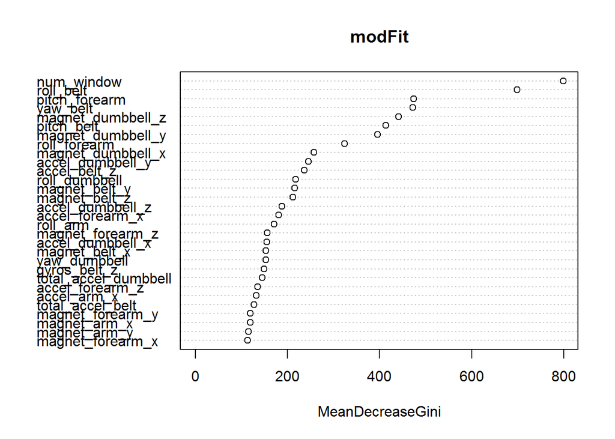

```r
modFit <- randomForest(classe ~., data = train1, importance  = TRUE, ntree = 100)

varImpPlot(modFit, type = 2)
```

```r
correl = cor(train1[,c("yaw_belt","roll_belt","num_window","pitch_belt","magnet_dumbbell_z","magnet_dumbbell_y","pitch_forearm","accel_dumbbell_y","roll_arm","magnet_dumbbell_x")])

which(abs(correl)>0.75, arr.ind = TRUE)
```

```
##                   row col
## yaw_belt            1   1
## roll_belt           2   1
## yaw_belt            1   2
## roll_belt           2   2
## num_window          3   3
## pitch_belt          4   4
## magnet_dumbbell_z   5   5
## magnet_dumbbell_y   6   6
## magnet_dumbbell_x  10   6
## pitch_forearm       7   7
## accel_dumbbell_y    8   8
## roll_arm            9   9
## magnet_dumbbell_y   6  10
## magnet_dumbbell_x  10  10
```

This shows there are four variables that may have a significant influence on each other (roll_belt & yaw_belt) and (magnet_dumbbel_x & magnet_dumbbel_y).

```r
cor(train1$roll_belt, train1$yaw_belt)
cor(train1$magnet_dumbbell_x, train1$magnet_dumbbell_y)

correl = cor(train1[,c("yaw_belt","roll_belt","num_window","pitch_belt","magnet_dumbbell_z","magnet_dumbbell_y","pitch_forearm","accel_dumbbell_y","roll_arm")])

which(abs(correl)>0.75, arr.ind = TRUE)

cor(train1$roll_belt, train1$yaw_belt)

correl = cor(train1[,c("roll_belt","num_window","pitch_belt","magnet_dumbbell_z","magnet_dumbbell_y","pitch_forearm","accel_dumbbell_y","roll_arm")])

which(abs(correl)>0.75, arr.ind = TRUE)
```

[output not shown]

With the above code, magnet_dumbbell_x and yaw_belt were removed because of their influence on other variables. The following variables were used to fit a model used in this project: “roll_belt”,“num_window”,“pitch_belt”,“magnet_dumbbell_z”,“magnet_dumbbell_y”,“pitch_forearm”,“accel_dumbbell_y”,“roll_arm”.

With 8 variables, the number of confounding factors is limited, and the model will not be overfit (only applicable to the dataset it was built off of).

## Modeling

The Random Forest algorithm was chosen because it seemed like a good choice based on the class lectures. As a point of comparison the decision tree algorithm was used to determine if there was a better choice.

Random Forest:

```r
modFit1 <- train(classe ~ roll_belt+num_window+pitch_belt+magnet_dumbbell_z+magnet_dumbbell_y+pitch_forearm+accel_dumbbell_y+roll_arm, data = train1, method = "rf", trControl = trainControl(method = "cv", number = 2))

print(modFit1, digits = 4)
```

```
## Random Forest
##
## 11776 samples
##     8 predictor
##     5 classes: 'A', 'B', 'C', 'D', 'E'
##
## No pre-processing
## Resampling: Cross-Validated (2 fold)
## Summary of sample sizes: 5887, 5889
## Resampling results across tuning parameters:
##
##   mtry  Accuracy  Kappa
##   2     0.9933    0.9915
##   5     0.9946    0.9931
##   8     0.9918    0.9896
##
## Accuracy was used to select the optimal model using  the largest value.
## The final value used for the model was mtry = 5.
```

Decision tree:

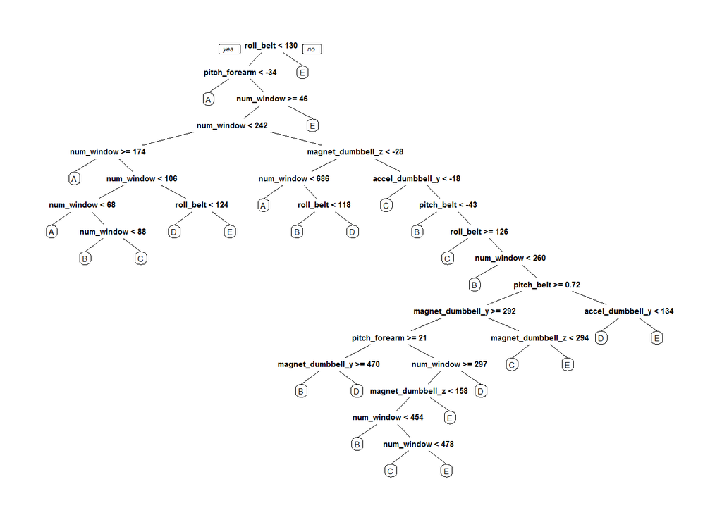

```r
modFit2 <- rpart(classe ~ roll_belt+num_window+pitch_belt+magnet_dumbbell_z+magnet_dumbbell_y+pitch_forearm+accel_dumbbell_y+roll_arm, data = train1, method = "class")
prp(modFit2)
```

### Accuracy

Accuracy of modFit1

```r
predictMF1 <- predict(modFit1, train2)
confMatrix1 <- confusionMatrix(predictMF1, train2$classe)
confMatrix1
```

```
## Confusion Matrix and Statistics
##
##           Reference
## Prediction    A    B    C    D    E
##          A 2232    1    0    0    0
##          B    0 1514    2    0    1
##          C    0    3 1366    2    1
##          D    0    0    0 1284    2
##          E    0    0    0    0 1438
##
## Overall Statistics
##
##                Accuracy : 0.9985
##                  95% CI : (0.9973, 0.9992)
##     No Information Rate : 0.2845
##     P-Value [Acc > NIR] : < 2.2e-16
##
##                   Kappa : 0.9981
##  Mcnemar's Test P-Value : NA
##
## Statistics by Class:
##
##                      Class: A Class: B Class: C Class: D Class: E
## Sensitivity            1.0000   0.9974   0.9985   0.9984   0.9972
## Specificity            0.9998   0.9995   0.9991   0.9997   1.0000
## Pos Pred Value         0.9996   0.9980   0.9956   0.9984   1.0000
## Neg Pred Value         1.0000   0.9994   0.9997   0.9997   0.9994
## Prevalence             0.2845   0.1935   0.1744   0.1639   0.1838
## Detection Rate         0.2845   0.1930   0.1741   0.1637   0.1833
## Detection Prevalence   0.2846   0.1933   0.1749   0.1639   0.1833
## Balanced Accuracy      0.9999   0.9984   0.9988   0.9991   0.9986
```

Accuracy of modFit2

```r
predictMF2 <- predict(modFit2, train2, type = "class")
confMatrix2 <- confusionMatrix(predictMF2, train2$classe)
confMatrix2
```

```
## Confusion Matrix and Statistics
##
##           Reference
## Prediction    A    B    C    D    E
##          A 1900  102    1   16    6
##          B  146 1071   31   55   19
##          C    7  123 1205   84   59
##          D  138  115  120 1041   57
##          E   41  107   11   90 1301
##
## Overall Statistics
##
##                Accuracy : 0.8307
##                  95% CI : (0.8223, 0.839)
##     No Information Rate : 0.2845
##     P-Value [Acc > NIR] : < 2.2e-16
##
##                   Kappa : 0.7869
##  Mcnemar's Test P-Value : < 2.2e-16
##
## Statistics by Class:
##
##                      Class: A Class: B Class: C Class: D Class: E
## Sensitivity            0.8513   0.7055   0.8808   0.8095   0.9022
## Specificity            0.9777   0.9603   0.9579   0.9345   0.9611
## Pos Pred Value         0.9383   0.8101   0.8153   0.7077   0.8394
## Neg Pred Value         0.9430   0.9315   0.9744   0.9616   0.9776
## Prevalence             0.2845   0.1935   0.1744   0.1639   0.1838
## Detection Rate         0.2422   0.1365   0.1536   0.1327   0.1658
## Detection Prevalence   0.2581   0.1685   0.1884   0.1875   0.1976
## Balanced Accuracy      0.9145   0.8329   0.9194   0.8720   0.9317
```

The accuracy of modFit2 is 83.07%.

Based on the accuracy modFit1 (Random Forest) was chosen as the preferred model for this project.

### Quiz Submission

```r
predictTest <- predict(modFit1, testDS)
```